# Panel Data Analysis

Mukund Singh Kathait

```r
# Read data

setwd("C:/Users/mukun/Downloads")
library("readxl")
d <- read_excel("BigMartSales.xlsx", sheet="Data")
str(d)
```

```
## tibble [8,523 x 12] (S3: tbl_df/tbl/data.frame)
##  $ Item_ID         : chr [1:8523] "FDA15" "DRC01" "FDN15" "FDX07" ...
##  $ Item_Weight     : num [1:8523] 9.3 5.92 17.5 19.2 8.93 ...
##  $ Item_Fat_Content: chr [1:8523] "Low Fat" "Regular" "Low Fat" "Regular" ...
##  $ Item_Visibility : num [1:8523] 0.016 0.0193 0.0168 0 0 ...
##  $ Item_Type       : chr [1:8523] "Dairy" "Soft Drinks" "Meat" "Fruits and Vegetables" ...
##  $ Item_MRP        : num [1:8523] 249.8 48.3 141.6 182.1 53.9 ...
##  $ Outlet_ID       : chr [1:8523] "OUT049" "OUT018" "OUT049" "OUT010" ...
##  $ Outlet_Year     : num [1:8523] 1999 2009 1999 1998 1987 ...
##  $ Outlet_Size     : chr [1:8523] "Medium" "Medium" "Medium" NA ...
##  $ City_Type       : chr [1:8523] "Tier 1" "Tier 3" "Tier 1" "Tier 3" ...
##  $ Outlet_Type     : chr [1:8523] "Supermarket Type1" "Supermarket Type2" "Supermarket Type1" "Grocery Store" ...
##  $ Item_Sales      : num [1:8523] 3735 443 2097 732 995 ...
```

Preprocess Data

```r
col <- c("Item_ID", "Item_Fat_Content", "Item_Type", "Outlet_ID", "Outlet_Size", "City_Type", "Outlet_Type")
d[col] <- lapply(d[col], factor)
str(d)
```

```
## tibble [8,523 x 12] (S3: tbl_df/tbl/data.frame)
##  $ Item_ID         : Factor w/ 1559 levels "DRA12","DRA24",..: 157 9 663 1122 1298 759 697 739 441 991 ...
##  $ Item_Weight     : num [1:8523] 9.3 5.92 17.5 19.2 8.93 ...
##  $ Item_Fat_Content: Factor w/ 3 levels "low fat","Low Fat",..: 2 3 2 3 2 3 3 2 3 3 ...
##  $ Item_Visibility : num [1:8523] 0.016 0.0193 0.0168 0 0 ...
##  $ Item_Type       : Factor w/ 16 levels "Baking Goods",..: 5 15 11 7 10 1 14 14 6 6 ...
##  $ Item_MRP        : num [1:8523] 249.8 48.3 141.6 182.1 53.9 ...
##  $ Outlet_ID       : Factor w/ 10 levels "OUT010","OUT013",..: 10 4 10 1 2 4 2 6 8 3 ...
##  $ Outlet_Year     : num [1:8523] 1999 2009 1999 1998 1987 ...
##  $ Outlet_Size     : Factor w/ 3 levels "High","Medium",..: 2 2 2 NA 1 2 1 2 NA NA ...
##  $ City_Type       : Factor w/ 3 levels "Tier 1","Tier 2",..: 1 3 1 3 3 3 3 3 2 2 ...
##  $ Outlet_Type     : Factor w/ 4 levels "Grocery Store",..: 2 3 2 1 2 3 2 4 2 2 ...
##  $ Item_Sales      : num [1:8523] 3735 443 2097 732 995 ...
```

```r
d$Outlet_Type <- relevel(d$Outlet_Type, ref= "Grocery Store")
d$City_Type <- relevel(d$City_Type, ref= "Tier 1")
```

Check for missing values

```r
colSums(is.na(d))
```

```
##          Item_ID      Item_Weight Item_Fat_Content  Item_Visibility
##                0             1463                0                0
##        Item_Type         Item_MRP        Outlet_ID      Outlet_Year
##                0                0                0                0
##      Outlet_Size        City_Type      Outlet_Type       Item_Sales
##             2410                0                0                0
```

Since we have 2410 missing values under Outlet_Size, and Outlet_Size is a proxy for Outlet_ID, we will drop Outlet_Size from our analysis Exploratory Data Analysis

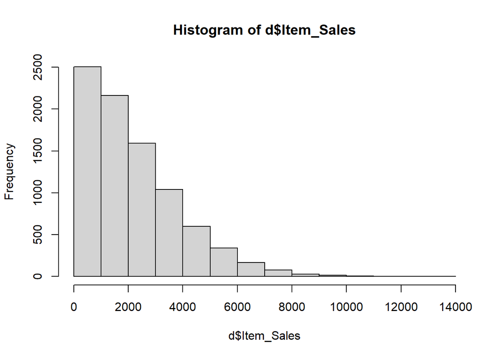

```r
hist(d$Item_Sales)
```

```r
table(d$Outlet_Type)
```

```
##
##     Grocery Store Supermarket Type1 Supermarket Type2 Supermarket Type3
##              1083              5577               928               935
```

```r
table(d$City_Type)
```

```
##
## Tier 1 Tier 2 Tier 3
##   2388   2785   3350
```

```r
table(d$City_Type, d$Outlet_Type)
```

```
##
##          Grocery Store Supermarket Type1 Supermarket Type2 Supermarket Type3
##   Tier 1           528              1860                 0                 0
##   Tier 2             0              2785                 0                 0
##   Tier 3           555               932               928               935
```

Variable selection for Mixed Level Analysis Dependent variable: Item_Sales Lower (item) level variables that affect item sales: Item_ID: Unit of analysis (will not be included in model) Item_Visibility: More visible products should sell more Item_Type: Certain item types such as dairy or vegetables may sell more Item_MRP: Pricier items may sell less Upper (store) level Variables that affect item sales Outlet_ID: Unit of analysis for upper-level (must be included in model) Outlet_Type: First part of analysis: how sales vary by outlet type City_Type: Second part of analysis: how sales vary by city type Outlet_Age: New variable; 2013 - Outlet_Year Note: Outlet_year (year of founding of outlet) doesn’t make sense as a predictor, but older outlets may have more established clientale and may sell more compared to new ones. We measure Outlet_Age as current year (2013) - year of founding

```r
d$Outlet_Age = 2013 - d$Outlet_Year
```

Mixed-level model using lmer Part 1: How item sales vary by outlet type (Grocery store, Supermarket Type 1, 2, 3)

```r
library(lme4)
#library(arm)
```

Very basic varying intercept model: random effect of outlet_type on item_sales This is a very basic model that does not control for item or store-level variables

```r
m1 <- lmer(Item_Sales ~ Outlet_Type + (1 | Outlet_ID), data=d)
summary(m1)
```

```
## Linear mixed model fit by REML ['lmerMod']
## Formula: Item_Sales ~ Outlet_Type + (1 | Outlet_ID)
##    Data: d
##
## REML criterion at convergence: 148671.9
##
## Scaled residuals:
##     Min      1Q  Median      3Q     Max
## -2.3207 -0.7146 -0.1249  0.4514  6.3140
##
## Random effects:
##  Groups    Name        Variance Std.Dev.
##  Outlet_ID (Intercept)    3468    58.89
##  Residual              2213059  1487.64
## Number of obs: 8523, groups:  Outlet_ID, 10
##
## Fixed effects:
##                              Estimate Std. Error t value
## (Intercept)                    339.83      61.47   5.529
## Outlet_TypeSupermarket Type1  1976.35      68.94  28.667
## Outlet_TypeSupermarket Type2  1655.66      98.14  16.871
## Outlet_TypeSupermarket Type3  3354.20      98.05  34.210
##
## Correlation of Fixed Effects:
##             (Intr) O_TST1 O_TST2
## Otlt_TypST1 -0.892
## Otlt_TypST2 -0.626  0.558
## Otlt_TypST3 -0.627  0.559  0.393
```

```r
#display(m1)
fixef(m1)
```

```
##                  (Intercept) Outlet_TypeSupermarket Type1
##                     339.8341                    1976.3480
## Outlet_TypeSupermarket Type2 Outlet_TypeSupermarket Type3
##                    1655.6646                    3354.2045
```

```r
ranef(m1)
```

```
## $Outlet_ID
##          (Intercept)
## OUT010 -2.244108e-01
## OUT013 -1.020178e+01
## OUT017  1.450057e+01
## OUT018  1.599543e-11
## OUT019  2.244108e-01
## OUT027  2.641623e-11
## OUT035  7.274518e+01
## OUT045 -7.338760e+01
## OUT046 -2.273678e+01
## OUT049  1.908042e+01
##
## with conditional variances for "Outlet_ID"
```

```r
coef(m1)
```

```
## $Outlet_ID
##        (Intercept) Outlet_TypeSupermarket Type1 Outlet_TypeSupermarket Type2
## OUT010    339.6097                     1976.348                     1655.665
## OUT013    329.6323                     1976.348                     1655.665
## OUT017    354.3347                     1976.348                     1655.665
## OUT018    339.8341                     1976.348                     1655.665
## OUT019    340.0585                     1976.348                     1655.665
## OUT027    339.8341                     1976.348                     1655.665
## OUT035    412.5793                     1976.348                     1655.665
## OUT045    266.4465                     1976.348                     1655.665
## OUT046    317.0973                     1976.348                     1655.665
## OUT049    358.9145                     1976.348                     1655.665
##        Outlet_TypeSupermarket Type3
## OUT010                     3354.204
## OUT013                     3354.204
## OUT017                     3354.204
## OUT018                     3354.204
## OUT019                     3354.204
## OUT027                     3354.204
## OUT035                     3354.204
## OUT045                     3354.204
## OUT046                     3354.204
## OUT049                     3354.204
##
## attr(,"class")
## [1] "coef.mer"
```

Better model: Varying intercept model with control variables

```r
m2 <- lmer(Item_Sales ~ Outlet_Type + Outlet_Age + Item_MRP + Item_Visibility +
      (1 | Outlet_ID), data=d)
summary(m2)
```

```
## Linear mixed model fit by REML ['lmerMod']
## Formula: Item_Sales ~ Outlet_Type + Outlet_Age + Item_MRP + Item_Visibility +
##     (1 | Outlet_ID)
##    Data: d
##
## REML criterion at convergence: 143948
##
## Scaled residuals:
##     Min      1Q  Median      3Q     Max
## -3.7903 -0.5946 -0.0780  0.5062  6.9996
##
## Random effects:
##  Groups    Name        Variance Std.Dev.
##  Outlet_ID (Intercept)    4582    67.69
##  Residual              1273456  1128.48
## Number of obs: 8523, groups:  Outlet_ID, 10
##
## Fixed effects:
##                                Estimate Std. Error t value
## (Intercept)                  -1763.1479   116.1374 -15.182
## Outlet_TypeSupermarket Type1  1931.2852    75.5517  25.562
## Outlet_TypeSupermarket Type2  1579.8205   123.4143  12.801
## Outlet_TypeSupermarket Type3  3365.5344   101.7327  33.082
## Outlet_Age                      -2.4417     4.3270  -0.564
## Item_MRP                        15.5612     0.1963  79.264
## Item_Visibility               -263.8193   247.3544  -1.067
##
## Correlation of Fixed Effects:
##             (Intr) O_TST1 O_TST2 O_TST3 Otlt_A It_MRP
## Otlt_TypST1 -0.782
## Otlt_TypST2 -0.749  0.656
## Otlt_TypST3 -0.096  0.343  0.115
## Outlet_Age  -0.798  0.445  0.611 -0.279
## Item_MRP    -0.237 -0.003 -0.003  0.001 -0.001
## Item_Vsblty -0.220  0.143  0.086  0.114 -0.004  0.000
## fit warnings:
## Some predictor variables are on very different scales: consider rescaling
```

```r
m3 <- lmer(Item_Sales ~ Outlet_Type + Outlet_Age + Item_MRP + Item_Visibility +
      (1 | Outlet_Type/Outlet_ID), data=d)
summary(m3)
```

```
## Linear mixed model fit by REML ['lmerMod']
## Formula: Item_Sales ~ Outlet_Type + Outlet_Age + Item_MRP + Item_Visibility +
##     (1 | Outlet_Type/Outlet_ID)
##    Data: d
##
## REML criterion at convergence: 143948
##
## Scaled residuals:
##     Min      1Q  Median      3Q     Max
## -3.7903 -0.5946 -0.0780  0.5062  6.9996
##
## Random effects:
##  Groups                Name        Variance Std.Dev.
##  Outlet_ID:Outlet_Type (Intercept)    4583    67.7
##  Outlet_Type           (Intercept)  423890   651.1
##  Residual                          1273456  1128.5
## Number of obs: 8523, groups:  Outlet_ID:Outlet_Type, 10; Outlet_Type, 4
##
## Fixed effects:
##                                Estimate Std. Error t value
## (Intercept)                  -1763.1482   661.3465  -2.666
## Outlet_TypeSupermarket Type1  1931.2853   923.8442   2.090
## Outlet_TypeSupermarket Type2  1579.8207   928.9846   1.701
## Outlet_TypeSupermarket Type3  3365.5342   926.3532   3.633
## Outlet_Age                      -2.4417     4.3273  -0.564
## Item_MRP                        15.5612     0.1963  79.264
## Item_Visibility               -263.8196   247.3544  -1.067
##
## Correlation of Fixed Effects:
##             (Intr) O_TST1 O_TST2 O_TST3 Otlt_A It_MRP
## Otlt_TypST1 -0.705
## Otlt_TypST2 -0.707  0.501
## Otlt_TypST3 -0.694  0.498  0.494
## Outlet_Age  -0.140  0.036  0.081 -0.031
## Item_MRP    -0.042  0.000  0.000  0.000 -0.001
## Item_Vsblty -0.039  0.012  0.011  0.012 -0.004  0.000
## fit warnings:
## Some predictor variables are on very different scales: consider rescaling
## optimizer (nloptwrap) convergence code: 0 (OK)
## unable to evaluate scaled gradient
## Model failed to converge: degenerate  Hessian with 1 negative eigenvalues
```

```r
library(stargazer)
stargazer(m1, m2, m3, type="html")
```

```
##
## <table style="text-align:center"><tr><td colspan="4" style="border-bottom: 1px solid black"></td></tr><tr><td style="text-align:left"></td><td colspan="3"><em>Dependent variable:</em></td></tr>
## <tr><td></td><td colspan="3" style="border-bottom: 1px solid black"></td></tr>
## <tr><td style="text-align:left"></td><td colspan="3">Item_Sales</td></tr>
## <tr><td style="text-align:left"></td><td>(1)</td><td>(2)</td><td>(3)</td></tr>
## <tr><td colspan="4" style="border-bottom: 1px solid black"></td></tr><tr><td style="text-align:left">Outlet_TypeSupermarket Type1</td><td>1,976.348<sup>***</sup></td><td>1,931.285<sup>***</sup></td><td>1,931.285<sup>**</sup></td></tr>
## <tr><td style="text-align:left"></td><td>(68.941)</td><td>(75.552)</td><td>(923.844)</td></tr>
## <tr><td style="text-align:left"></td><td></td><td></td><td></td></tr>
## <tr><td style="text-align:left">Outlet_TypeSupermarket Type2</td><td>1,655.665<sup>***</sup></td><td>1,579.820<sup>***</sup></td><td>1,579.821<sup>*</sup></td></tr>
## <tr><td style="text-align:left"></td><td>(98.137)</td><td>(123.414)</td><td>(928.985)</td></tr>
## <tr><td style="text-align:left"></td><td></td><td></td><td></td></tr>
## <tr><td style="text-align:left">Outlet_TypeSupermarket Type3</td><td>3,354.204<sup>***</sup></td><td>3,365.534<sup>***</sup></td><td>3,365.534<sup>***</sup></td></tr>
## <tr><td style="text-align:left"></td><td>(98.046)</td><td>(101.733)</td><td>(926.353)</td></tr>
## <tr><td style="text-align:left"></td><td></td><td></td><td></td></tr>
## <tr><td style="text-align:left">Outlet_Age</td><td></td><td>-2.442</td><td>-2.442</td></tr>
## <tr><td style="text-align:left"></td><td></td><td>(4.327)</td><td>(4.327)</td></tr>
## <tr><td style="text-align:left"></td><td></td><td></td><td></td></tr>
## <tr><td style="text-align:left">Item_MRP</td><td></td><td>15.561<sup>***</sup></td><td>15.561<sup>***</sup></td></tr>
## <tr><td style="text-align:left"></td><td></td><td>(0.196)</td><td>(0.196)</td></tr>
## <tr><td style="text-align:left"></td><td></td><td></td><td></td></tr>
## <tr><td style="text-align:left">Item_Visibility</td><td></td><td>-263.819</td><td>-263.820</td></tr>
## <tr><td style="text-align:left"></td><td></td><td>(247.354)</td><td>(247.354)</td></tr>
## <tr><td style="text-align:left"></td><td></td><td></td><td></td></tr>
## <tr><td style="text-align:left">Constant</td><td>339.834<sup>***</sup></td><td>-1,763.148<sup>***</sup></td><td>-1,763.148<sup>***</sup></td></tr>
## <tr><td style="text-align:left"></td><td>(61.466)</td><td>(116.137)</td><td>(661.347)</td></tr>
## <tr><td style="text-align:left"></td><td></td><td></td><td></td></tr>
## <tr><td colspan="4" style="border-bottom: 1px solid black"></td></tr><tr><td style="text-align:left">Observations</td><td>8,523</td><td>8,523</td><td>8,523</td></tr>
## <tr><td style="text-align:left">Log Likelihood</td><td>-74,335.950</td><td>-71,974.020</td><td>-71,974.020</td></tr>
## <tr><td style="text-align:left">Akaike Inf. Crit.</td><td>148,683.900</td><td>143,966.000</td><td>143,968.000</td></tr>
## <tr><td style="text-align:left">Bayesian Inf. Crit.</td><td>148,726.200</td><td>144,029.500</td><td>144,038.600</td></tr>
## <tr><td colspan="4" style="border-bottom: 1px solid black"></td></tr><tr><td style="text-align:left"><em>Note:</em></td><td colspan="3" style="text-align:right"><sup>*</sup>p<0.1; <sup>**</sup>p<0.05; <sup>***</sup>p<0.01</td></tr>
## </table>
```

```r
m4 <- lmer(Item_Sales ~ City_Type + (1 | Outlet_ID), data=d)

m5 <- lmer(Item_Sales ~ City_Type + Outlet_Type + Outlet_Age + Item_MRP +
      Item_Visibility + (1 | Outlet_ID), data=d)
m6 <- lmer(Item_Sales ~ City_Type + Outlet_Type + Outlet_Age + Item_MRP +
      Item_Visibility + (1 | City_Type/Outlet_ID), data=d)
stargazer(m4, m5, m6, type="text")
```

```
##
## =====================================================================
##                                        Dependent variable:
##                              ----------------------------------------
##                                             Item_Sales
##                                  (1)           (2)           (3)
## ---------------------------------------------------------------------
## City_TypeTier 2                667.789       -16.168       -16.168
##                               (889.568)     (112.171)     (277.767)
##
## City_TypeTier 3                426.387       -14.527       -14.527
##                               (832.189)     (93.286)      (270.693)
##
## Outlet_TypeSupermarket Type1              1,931.141***  1,931.141***
##                                             (96.306)      (96.307)
##
## Outlet_TypeSupermarket Type2              1,579.705***  1,579.705***
##                                             (189.086)     (189.088)
##
## Outlet_TypeSupermarket Type3              3,375.331***  3,375.331***
##                                             (138.504)     (138.506)
##
## Outlet_Age                                   -2.855        -2.855
##                                              (7.529)       (7.529)
##
## Item_MRP                                    15.561***     15.561***
##                                              (0.196)       (0.196)
##
## Item_Visibility                             -264.975      -264.975
##                                             (247.380)     (247.380)
##
## Constant                     1,656.178*** -1,746.776*** -1,746.776***
##                               (629.099)     (182.885)     (256.386)
##
## ---------------------------------------------------------------------
## Observations                    8,523         8,523         8,523
## Log Likelihood               -74,360.830   -71,963.180   -71,963.180
## Akaike Inf. Crit.            148,731.700   143,948.400   143,950.400
## Bayesian Inf. Crit.          148,766.900   144,025.900   144,035.000
## =====================================================================
## Note:                                     *p<0.1; **p<0.05; ***p<0.01
```

Interpretation:

Models m4, m5, and m6 had very different parameter estimates, but since m4 was very basic, and m5 and m6 parameters are stable and consistent, we use those models for interpretation. Items sell the highest in Tier 1 cities when controlled for item and outlet level differences. Outlets in Tier 2 and 3 cities sell $16 and $14 less compared to Tier 1; however these diferences are not statistically significant. Based on these findings, we infer that city tiers have no discernable impact on item sales.